# Prososal

Nhom 4

7/4/2022

Thành viên nhóm

19133025 Đinh Quốc Hùng

19133010 Trần Nguyên Thái Bảo

19133049 Đoàn Nhất Sinh

19133023 Lê Tuấn Hiệp

Tên đề tài :

Nhận diện chữ số (Digit recognition)

## **Phần 1 : Giới thiệu**

Nhận dạng chữ số viết tay là khả năng máy tính nhận dạng chữ số viết tay của con người. Đó là một nhiệm vụ khó khăn cho cỗ máy vì các chữ số viết tay không hoàn hảo và có thể được tạo ra với nhiều kiểu cách khác nhau. Nhận dạng chữ số viết tay là giải pháp cho vấn đề này sử dụng hình ảnh của một chữ số và nhận dạng chữ số hiện diện trong hình ảnh.

## **Phần 2 : Dữ liệu**

Tập dữ liệu được lấy từ: https://www.kaggle.com/competitions/digit-recognizer/data

Các tệp dữ liệu train.csv và test.csv chứa hình ảnh thang màu xám của các chữ số vẽ tay, từ 0 đến 9.

Mỗi hình ảnh có chiều cao 28 pixel và chiều rộng 28 pixel, tổng cộng là 784 pixel. Mỗi pixel có một giá trị pixel duy nhất được liên kết với nó, cho biết độ sáng hoặc tối của pixel đó, với các con số cao hơn có nghĩa là tối hơn. Giá trị pixel này là một số nguyên từ 0 đến 255, bao gồm cả.

Tập train.csv có 785 cột. Trong đó cột đầu tiên là nhãn và phần còn lại của các cột chứa các giá trị pixel của hình ảnh được liên kết.

Đây là 10 dòng đầu tập train

```
##    label pixel0 pixel1 pixel2 pixel3 pixel4 pixel5 pixel6 pixel7 pixel8 pixel9
## 1      1      0      0      0      0      0      0      0      0      0      0
## 2      0      0      0      0      0      0      0      0      0      0      0
## 3      1      0      0      0      0      0      0      0      0      0      0
## 4      4      0      0      0      0      0      0      0      0      0      0
## 5      0      0      0      0      0      0      0      0      0      0      0
## 6      0      0      0      0      0      0      0      0      0      0      0
## 7      7      0      0      0      0      0      0      0      0      0      0
## 8      3      0      0      0      0      0      0      0      0      0      0
## 9      5      0      0      0      0      0      0      0      0      0      0
## 10     3      0      0      0      0      0      0      0      0      0      0
##    pixel10 pixel11 pixel12 pixel13 pixel14 pixel15 pixel16 pixel17 pixel18
## 1        0       0       0       0       0       0       0       0       0
## 2        0       0       0       0       0       0       0       0       0
## 3        0       0       0       0       0       0       0       0       0
```

[output cut: 1052 more lines]

Mỗi cột pixel trong tập train có tên như pixelx, trong đó x là số nguyên từ 0 đến 783, bao gồm cả. Để xác định vị trí pixel này trên hình ảnh, giả sử rằng chúng ta đã phân tách x thành x = i * 28 + j, trong đó i và j là các số nguyên từ 0 đến 27, bao gồm cả. Khi đó pixelx nằm trên hàng i và cột j của ma trận 28 x 28, (lập chỉ mục bằng 0).

7 dòng đầu tập test

```
##   pixel0 pixel1 pixel2 pixel3 pixel4 pixel5 pixel6 pixel7 pixel8 pixel9 pixel10
## 1      0      0      0      0      0      0      0      0      0      0       0
## 2      0      0      0      0      0      0      0      0      0      0       0
## 3      0      0      0      0      0      0      0      0      0      0       0
## 4      0      0      0      0      0      0      0      0      0      0       0
## 5      0      0      0      0      0      0      0      0      0      0       0
## 6      0      0      0      0      0      0      0      0      0      0       0
## 7      0      0      0      0      0      0      0      0      0      0       0
##   pixel11 pixel12 pixel13 pixel14 pixel15 pixel16 pixel17 pixel18 pixel19
## 1       0       0       0       0       0       0       0       0       0
## 2       0       0       0       0       0       0       0       0       0
## 3       0       0       0       0       0       0       0       0       0
## 4       0       0       0       0       0       0       0       0       0
## 5       0       0       0       0       0       0       0       0       0
## 6       0       0       0       0       0       0       0       0       0
```

[output cut: 761 more lines]

Ví dụ: pixel31 cho biết pixel nằm trong cột thứ tư từ bên trái và hàng thứ hai từ trên cùng, như trong biểu đồ bên dưới.

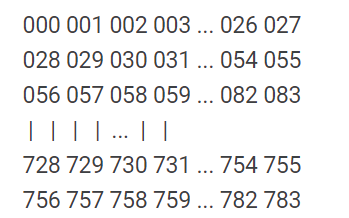

Kích thước của tập train và test.

```
## [1] 42000   785
```

```
## [1] 28000   784
```

Đổi kiểu dữ liệu labe thành factor.

```
##     label    pixel0    pixel1    pixel2    pixel3    pixel4
##  "factor" "integer" "integer" "integer" "integer" "integer"
```

Trực quán hóa dữ liệu

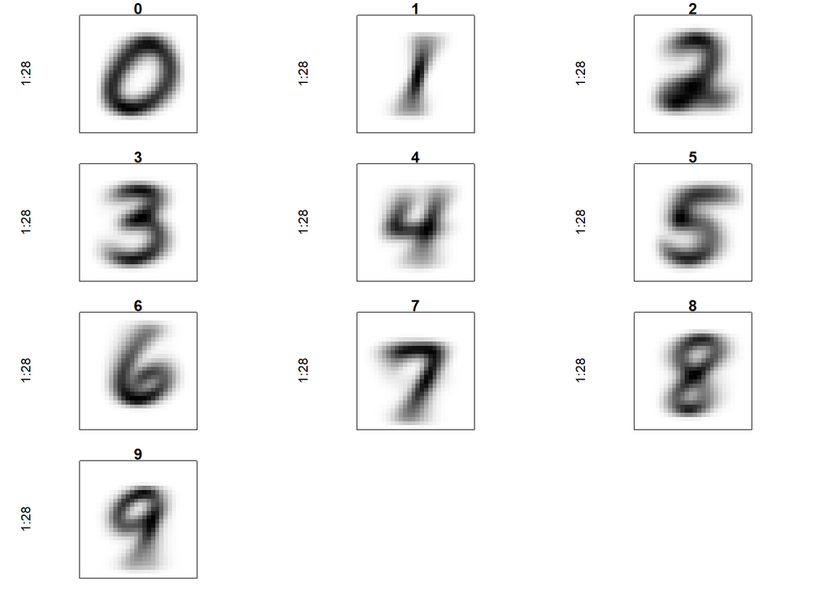

Dựa vào kết quả trực quan trên ta thấy các số khá mờ nên rất dễ dẫn đến việc dữ đoán sai đối với mỗi số.

Kiểm tra phần trăm các nhãn trong tập train

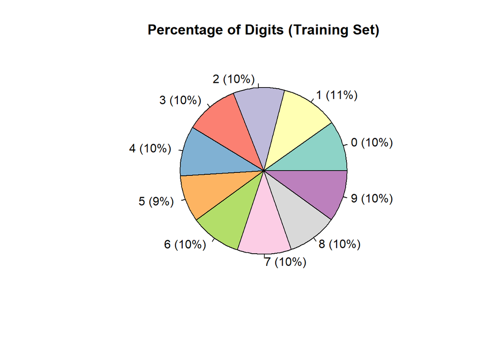

## **Phần 3 : Kế hoạch đối với đề tài.**

**Mục tiêu của đề tài:** đối với từng record trên tập test thì ta cần phải đoán đúng nhãn của nó là gì.

- Sử dụng các thuật toán phân loại để xác định nhãn.
- Sử dụng các thuật toán phân loại và đánh giá các thuật toán. Các thuật toán nhóm dự kiến sử dụng: K-nn, decision tree, random forest